# Showcasing

```r
knitr::opts_chunk$set(echo = TRUE)
library(terra)
library(lattice)
library(imager)
library(parallel)
```

# Function Explanation

## The basic logic of the function is:

- Dissects the matrix in smaller kernels (can be also the whole image)
- Extract SWF edges with the Canny algotithm (sigma user defined)
- Finds spatial indexes of AgriCat cells
- Finds indexes of SWF cells that fall on edges (attractors)
- Finds indexes of SWF cells that do not fall on edges (movable cells)
- Picks edge SWF from a low, medium or high SWF density area (user defined) which is then used as an “attractor”
- Picks Q (number is user defined) agri cell that are the closest neighbours to the attractor favouring diagonal neighbour to avoid straight lines
- Picks the Q (number is user defined) non-edge SWF farthest from the attractor which are the SWF that move.
- Saves the rearrenged matrix which is used for the next iteration

## Function options

- `Hmatrix` A matrix representing the initial habitat state.
- `swfCat` Integer representing habitat category in the matrix.
- `agriCat` Integer representing non-habitat category in the matrix.
- `foreCat` Integer representing fores (habitat) category in the matrix.
- `Q` Integer representing the number of cells to be moved in each kernel per iteration.
- `iterations` Number of iterations for the aggregation process.
- `kernelCl` Vertical size of the kernel for processing.
- `kernelRw` Horizontal size of the kernel for processing.
- `NNeighbors` Threshold of neighbours in a kernel below which habitat pixels are moved in a kernel.
- `maxDistance` Searching radius for habitat pixel aggregation.
- `Density` Strategy for selecting the cell as a gravity center. “H” to choose area with high habitat cover, “L” from low, “M” for median density.
- `queensCase` If TRUE, all 8 directions are considered for neighbors; if FALSE, only orthogonal neighbors are considered.
- `np Number` of cores for parallel processing.
- `deBug` If TRUE, debugging information is provided.

## Import raster

```r
# Load the raster data
swf.raster <- rast('/home/matteo/own_data/PoD/jrc/data/subset/clc_swf_10m.tif')
swt.mt <- t(as.matrix(swf.raster, wide=T))
storage.mode(swt.mt) <- "integer"
```

## Run function

```r
iters <- 50
smf.L <- swf.clumper.regular(Hmatrix=swt.mt, swfCat=1, agriCat=2, foreCat=3, sigma=2, Q=5, iterations=iters, kernelCl=100, kernelRw=100, NNeighbors=3, queensCase=TRUE, np=7, maxDistance = 2, Density="L", deBug=FALSE)
```

## Plot results

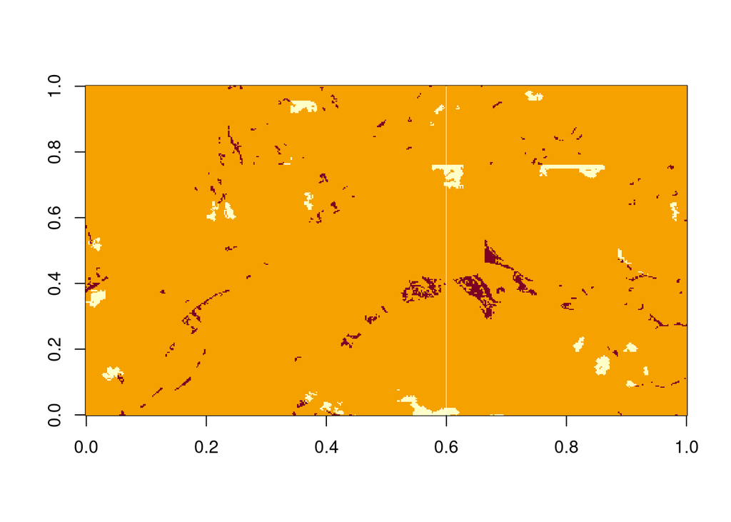

```r
diff <- smf.L[[length(smf.L)]] - swt.mt
image(diff)
```

```r
layout_matrix <- matrix(c(1, 2, 3), ncol = 1, byrow = TRUE)
trellis.par.set(layout.heights = list(top.padding = 1, main.key.padding = 1.5, key.axis.padding = -1, axis.xlab.padding = -1, bottom.padding = -1))
trellis.par.set(layout.widths = list(left.padding = -1, key.ylab.padding = -1, right.padding = -1))
```

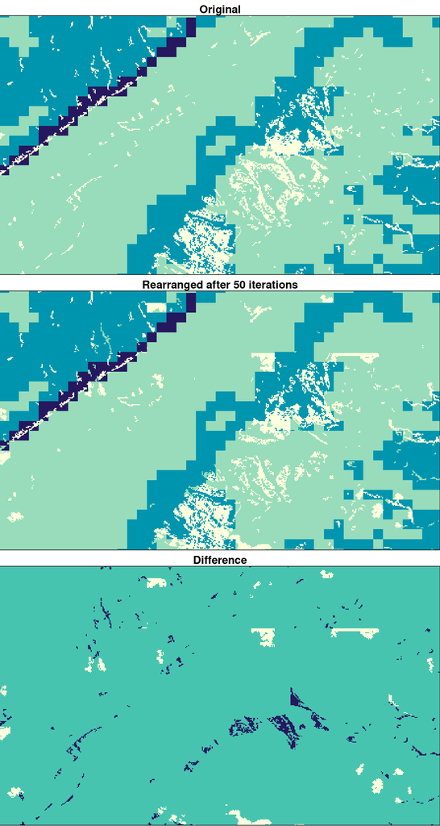

```r
print(levelplot(swt.mt, colorkey=FALSE, xlab="", ylab="", main="Original", scales=list(x=list(draw=FALSE), y=list(draw=FALSE))),  split=c(1, 1, 1, 3), more=TRUE)
print(levelplot(smf.L[[length(smf.L)]], colorkey=FALSE, xlab="", ylab="", main=paste("Rearranged after", iters, "iterations"), scales=list(x=list(draw=FALSE), y=list(draw=FALSE))),  split=c(1, 2, 1, 3), more=TRUE)
print(levelplot(diff, colorkey=FALSE, xlab="", ylab="", main="Difference", scales=list(x=list(draw=FALSE), y=list(draw=FALSE))),
      split=c(1, 3, 1, 3), more=FALSE)
```